# Baseball’s Diverse Pitches and Pitchers

Eliot Chignell

## Background

I have been an avid baseball fan for several years, and I am specifically captivated by the wide range of different pitches and their effects on the game’s outcomes. Additionally, baseball is an excellent sport to analyse with statistics, given its rigid game structure and discrete outcomes (as opposed to more dynamic, free-flowing sports like football and rugby).

To collect the data used for this report, I used a Google Form to log a subset of pitches from several MLB games on the 30th of March and the 12th of May (80 observations in total). For each pitch, I noted down some data about the pitcher (pitcher name and handedness) and the pitch itself (velocity, game outcome and pitch type).

With this data, I was able to explore some different questions:

## What type of pitches are most effective for pitchers?

> Pitchers throw several different types of pitches, and each has a different mix of velocity and movement (incurred by spin on the baseball through the air). For example, a standard four-seam fastball is often a pitcher’s quickest pitch with the least “movement”, whereas a curve ball is often the slowest with a more extreme “looping” motion towards the plate.

The plot below shows the proportion of pitches with a good outcome for the pitcher (strike, foul ball, or out) by different pitch type (I have filtered out pitch types with less than 3 observations due to minimal statistical significance).

From this sample of data, we can see that sliders are the most effective (by a considerable margin), compared to the less effective sinkers.

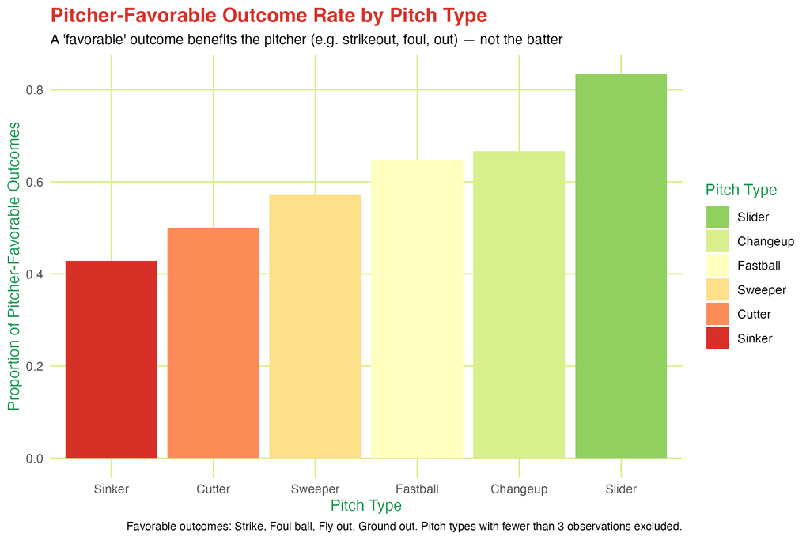

Bar chart comparing pitcher-favourable outcome rates across pitch types. Each bar represents a pitch type, ordered left to right from lowest to highest favourable rate. A ‘favourable’ outcome benefits the pitcher, such as a strikeout, foul ball, or out. The chart reveals which pitch types are most effective for the pitcher.

## What is the correlation between pitch type and pitch velocity?

Next, I explored the link between pitch type and velocity in this dataset. Overall, the pitches range from around 80-100 miles per hour, and there does appear to be a correlation between pitch type and velocity.

Specifically, fastballs and sinkers are clearly quicker than the other types - with speeds ranging from about 92-99 mph, compared to others sitting around 80-90 mph. This does make sense, as both are technically different types of fastball.

> I designated the four-seam fastball as just “fastball”, and a sinker is essentially a two-seam fastball.

The category of fastball is self-explanatory, it consists of pitches which are thrown the hardest and which have pitching mechanics that allow them to be the quickest of a pitcher’s arsenal.

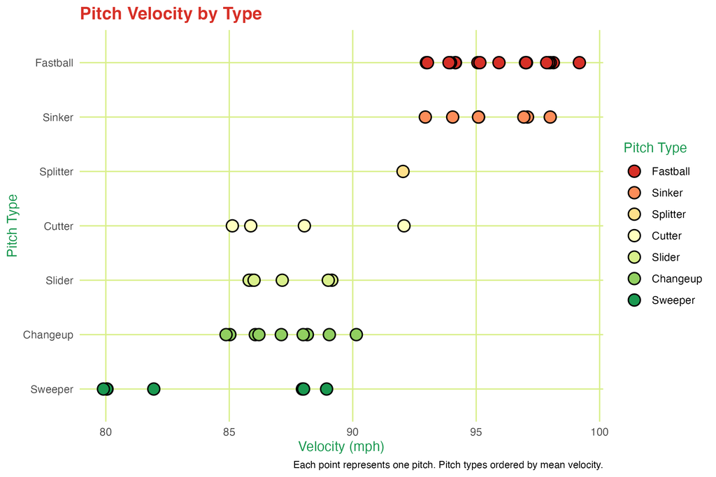

Dot plot showing the spread and distribution of pitch velocities in miles per hour for each pitch type. Pitch types are arranged vertically in order of mean velocity. Each dot is an individual pitch, spread horizontally to show variation within each type, making it easy to compare both typical speed and consistency across pitch types.

> My choice of colour scheme originated from this plot - with quicker pitches usually depicted in red on broadcasts.

## How quick/slow do some pitchers throw compared to others?

For the second data collection on the 12th of May, I tuned into several different games across an hour in the afternoon (when MLB games are typically on in the New Zealand timezone). This can be seen in the plot below as the colours (representing different pitchers) fall into vertical bands.

Consistent with the previous plots, one can see how pitches range in velocity - and while it’s not directly demonstrated in this graph, the same pitch type for a specific pitcher often clumps together with respect to velocity.

What’s more revealing is the velocity ranges of different pitchers: George Kirby throws the most pitches quicker than 95 miles per hour, as opposed to Peter Lambert who mostly throws pitches between 85-90 miles per hour.

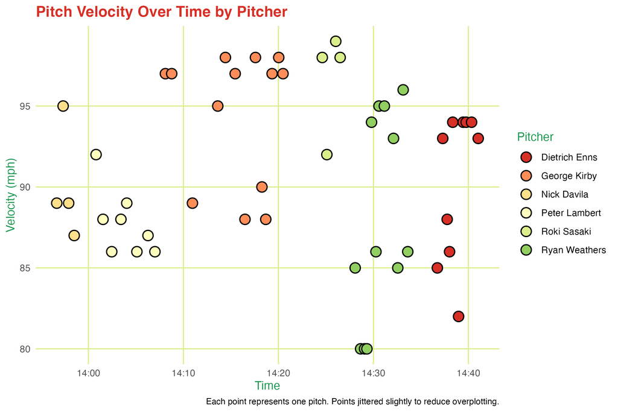

Scatter plot tracking pitch velocity in miles per hour over time, with each dot representing a single pitch colored by pitcher. The horizontal axis shows time, allowing the viewer to see when data for each pitch was collected and how they group together with each pitcher. Points are slightly spread to reduce overlap.

## Conclusion

Overall, this data exploration revealed some interesting (albeit expected) insights into baseball pitchers and pitches in the MLB. I do acknowledge that the sample size of around 80 pitches spread across a handful of pitchers is too small to infer any strong conclusions.

Next time I would definitely automate the data collection process by using API’s (or web scraping if necessary) and collecting even more data points to find more statistically significant relationships. Ideally, I would love to translate my statistical findings into expressions of winning value (like WAR - wins above replacement).